# Phases in BML traffic model

### The trajectories of the average velocity of the cars

These trajectories also help to characterize the phases. The following graph show three example of the trajectories.

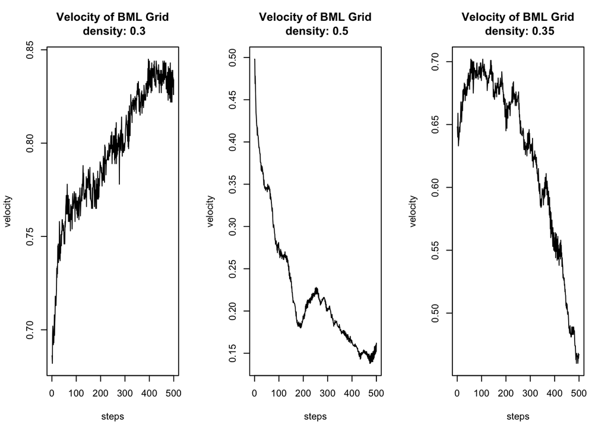

```r
par(mfrow=c(1,3))
SimulateBML::plotBMLVelocities(density = .3, numSteps = 500, measureEvery = 1)
SimulateBML::plotBMLVelocities(density = .5, numSteps = 500, measureEvery = 1)
SimulateBML::plotBMLVelocities(density = .35, numSteps = 500, measureEvery = 1)
```

## How does the shape of the grid affect the result

It is suprising that the shape of the grid doesn’t seem to change the phase transition dramatically. I looked at from $100 \times 10$ grids, $100 \times 20$ grids all the way up to $100 \times 120$ grids. And I used the densities of 0.2, 0.4 and 0.6 (the number of red cars equals to the number of blue cars). The basic results are the same. There are 3 phases for these grids at different densities (graphs not included).